# Clustering: K-means

## Where we’ve been

- **Days 9–18: supervised.** Every row had a \(y\) (private? heavy debt?).
  - Predict \(y\) from the \(x\)’s; judge with CV error.
- **Today: unsupervised.** No \(y\), only the \(x\)’s.
  - Are there groups of similar rows?
- No \(y\) means **no CV error**: no right answer to check.

## Same points, with and without labels

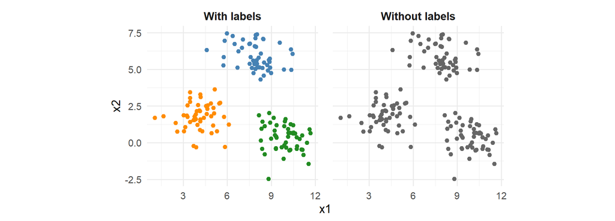

- Left: Days 11–18 (logistic, KNN, trees) learn to predict the group.
- Right: no groups given. **Can we find them from `x1` and `x2` alone?**

## Why cluster?

- **Customer segments:** market to each type of shopper differently.
- **Peer schools:** compare test scores among similar schools.
- **Recommendations:** group similar songs, articles, products.
- Three methods in the next three classes:
  - **K-means** (today) and **hierarchical clustering** (Day 20): group the **rows**.
  - **PCA** (Day 21): combine the **columns** into a few summaries.

## Clustering the world’s cities

> **4,251 cities of 100,000+. Only longitude and latitude, no country. K = 6.**

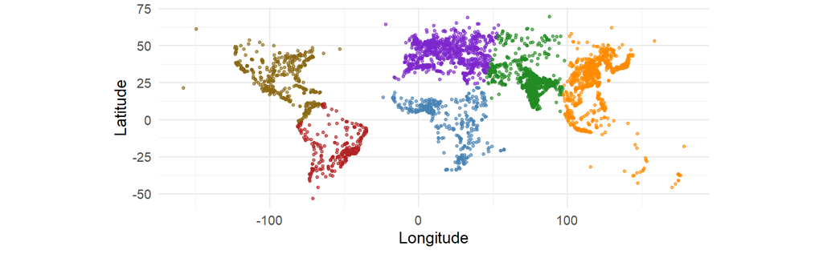

- The clusters look like continents. **Why?** K-means never heard of one.
- Where would you group the cities differently?

## K-means: the goal

> **The same 150 points, two ways to make K = 3 clusters. Which is better?**

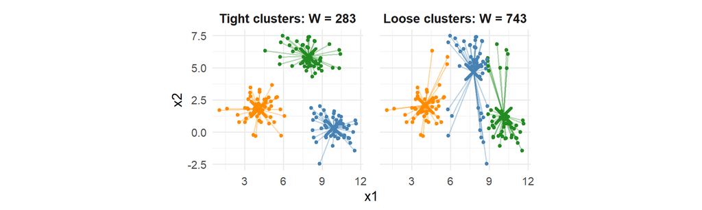

- Pick \(K\). Each **centroid** (×) is the average of its cluster’s points.
- **W** adds up the **squared** line lengths: \(\sum_k \sum_{i \in C_k} \sum_j (x_{ij} - \bar{x}_{kj})^2\).
- K-means looks for the clusters with the **smallest W**.

## Can’t we just try every split?

- 150 points into 3 groups: about \(10^{70}\) ways. Too many.
- Instead (ISL Algorithm 12.2):
  1. Put each point in a cluster **at random**.
  2. Compute each cluster’s **centroid**.
  3. Move each point to the **closest** centroid.
  4. Repeat 2–3 until no point moves.

## Step 1: random clusters

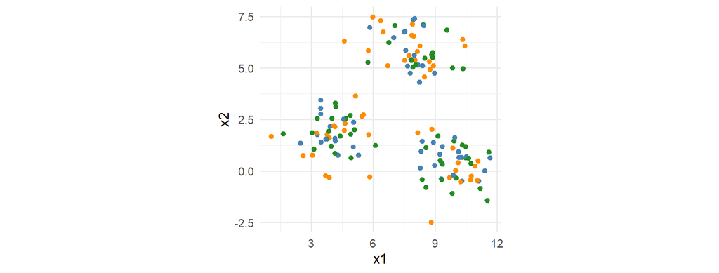

- Each point gets cluster 1, 2, or 3 at random. W = **1979**.

## Step 2: compute the centroids

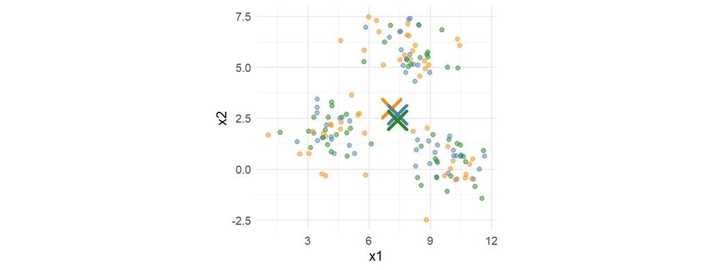

- **×** = each centroid. Random clusters put all three near the middle.

## Step 3: move to the closest centroid

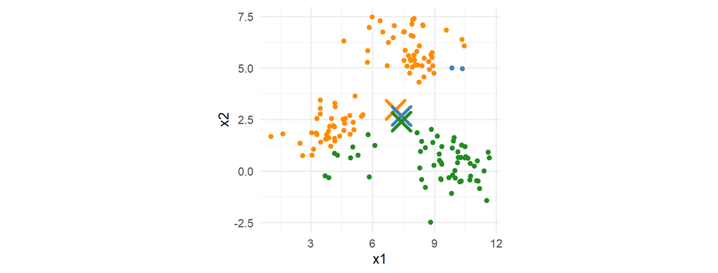

- Each point takes the color of the **nearest ×**. W: 1979 → **1123**.

## Repeat until nothing changes

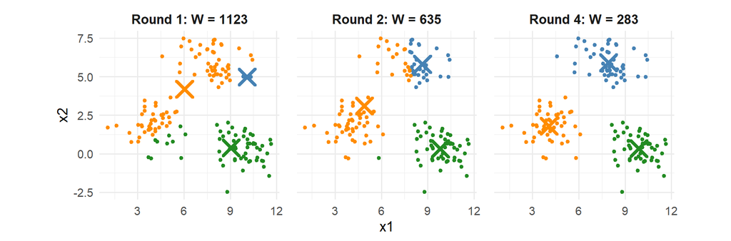

- The centroids walk out to the groups. After 4 rounds, no point moves.
- W **never goes up**: each step can only shorten the lines.

## Each start can end differently

- K-means can stop at a **worse** split. 14 of 300 random starts got stuck:

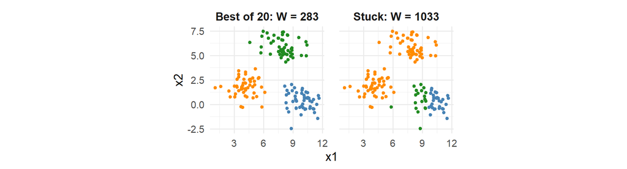

- Fix: try many starts, **keep the smallest W** (`nstart = 20`).

## K-means in R

```r
set.seed(19)                                 # the starts are random
km <- kmeans(blobs[, c("x1", "x2")],         # numeric columns only
             centers = 3,                    # K
             nstart = 20)                    # random starts; keeps the best
km$size                                      # points per cluster
## [1] 50 50 50
km$centers                                   # centroids
##         x1        x2
## 1 4.080710 1.7960817
## 2 9.898626 0.3417214
## 3 7.929049 5.9001490
km$tot.withinss                              # W
## [1] 283.442
```

- `km$cluster`: each point’s cluster. Add it to the data with `mutate()`.

## How many clusters?

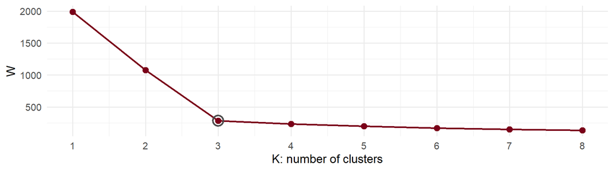

- More clusters **always** lower W. With \(K = n\), W = 0.
- Look for the **elbow**: big drops up to K = 3, small ones after.

## What K = 6 does

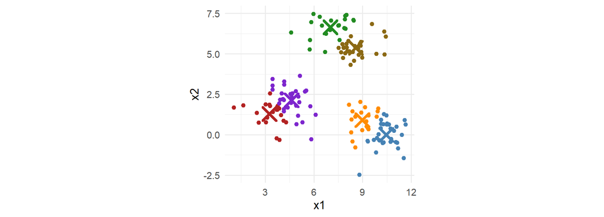

- W falls (283 → 167), but each real group is just cut in two.
- Choosing \(K\) is a **judgment call**: the elbow, plus the use.

## Units matter

> **300 shoppers: age (years) and income (dollars). K = 3.**

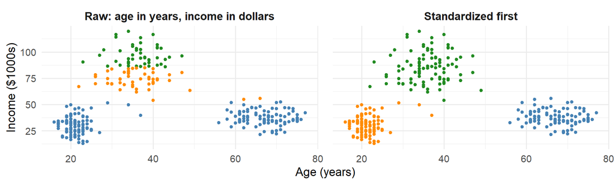

- **Raw:** $1,000 counts as much as 1,000 years. K-means only sees income.
- **Standardized:** both columns count. Three clear groups.

## Standardize first

- Distances depend on **units** (KNN on Day 13, k-means today).
- `scale()` puts each column in SDs: (x − mean) / SD.

```r
km <- kmeans(scale(shoppers), centers = 3, nstart = 20)
```

- Skip it only if the units **should** count (the cities: both in degrees).

## Describe the clusters

> **The standardized clusters, described in the original units:**

| Shoppers | Average age | Average income | A name? |
| --- | --- | --- | --- |
| 103 | 21 | $30,000 | Students |
| 97 | 36 | $86,000 | Young professionals |
| 100 | 67 | $38,000 | Retirees |

- K-means gives cluster **numbers**; naming them is our job.
- Compare them with `group_by()` + `summarise()`, even on **unused** columns.

## Summary

- **Unsupervised:** no \(y\), no CV error. Find groups of similar rows.
- **K-means:** \(K\) clusters with the smallest W.
- **Algorithm:** random → centroids → move to closest → repeat.
- **Many starts** (`nstart = 20`): keep the smallest W.
- **Choose \(K\):** the elbow, plus the use.
- **Standardize** first (`scale()`).
- **Day 20:** hierarchical clustering, no \(K\) up front.

## For rest of class

- Work on the `day19_activity`
  - back to the `College` data, but no \(y\) this time: which colleges are alike?
  - k-means on raw, then standardized columns: which does it see?
  - choose K, and find Claremont McKenna’s peers
- Ask me questions if you run into issues